# QUALITY OF WINE

"Wine is the most healthy and most hygienic of beverages." Wine classification is a difficult task since taste is the least understood of the human sense.  
There are several features to predict the wine quality but the entire features will not be relevant for better prediction.

## Dataset

The Red Wine Quality dataset contains information about various physicochemical properties of wines.

The dataset only has numeric variables:

Fixed Acidity: Influences the flavor of the wine. A significant reduction in acids can lead to wines that taste flat.

Volatile Acidity: Excesss of volatile acids are undesirable and lead to unpleasant flavor.

Residual Sugar: The amount of sugar remaining after the end of the fermentation.

Chlorides: The amount of salt in the wine.

Free Sulphur dioxide: The amount of SO2 in free form.

Total Sulphur dioxide: The total amount of SO2 in the wine.

Density: It is the measure of the conversation of sugar to alcohol.

pH: Describes how acidic or basic a wine is on a scale of 0 (very acidic) to 14 (very basic).

Sulphates: The amount of mineral salts containing sulphur in thw wine.

Alcohol: Alcohol is formed as a result of yeast converting sugar during the fermentation process.

Quality: A quality label in the range of 0 (very bad) to 10 (very excellent).

## Importing the libraries

```python
import numpy as np
import pandas as pd
import warnings
warnings.filterwarnings("ignore")
import matplotlib.pyplot as plt
%matplotlib inline
import seaborn as sns
import os
import math
from collections import Counter
```

```python
data=pd.read_csv('Red_wine.csv')
```

```python
data
```

|  | fixed acidity | volatile acidity | citric acid | residual sugar | chlorides | free sulfur dioxide | total sulfur dioxide | density | pH | sulphates | alcohol | quality |
| --- | --- | --- | --- | --- | --- | --- | --- | --- | --- | --- | --- | --- |
| 0 | 7.4 | 0.700 | 0.00 | 1.9 | 0.076 | 11.0 | 34.0 | 0.99780 | 3.51 | 0.56 | 9.4 | 5.0 |
| 1 | 7.8 | 0.880 | 0.00 | 2.6 | 0.098 | 25.0 | 67.0 | 0.99680 | 3.20 | 0.68 | 9.8 | 5.0 |
| 2 | 7.8 | 0.760 | 0.04 | 2.3 | 0.092 | 15.0 | 54.0 | 0.99700 | 3.26 | 0.65 | 9.8 | 5.0 |
| 3 | 11.2 | 0.280 | 0.56 | 1.9 | 0.075 | 17.0 | 60.0 | 0.99800 | 3.16 | 0.58 | 9.8 | 6.0 |
| 4 | 7.4 | 0.700 | 0.00 | 1.9 | 0.076 | 11.0 | 34.0 | 0.99780 | 3.51 | 0.56 | 9.4 | 5.0 |
| ... | ... | ... | ... | ... | ... | ... | ... | ... | ... | ... | ... | ... |
| 1594 | 6.2 | 0.600 | 0.08 | 2.0 | 0.090 | 32.0 | 44.0 | 0.99490 | 3.52 | 0.58 | 10.5 | 5.0 |
| 1595 | 5.9 | 0.550 | 0.10 | 2.2 | 0.062 | 39.0 | 51.0 | 0.99512 | 3.52 | 0.76 | 11.2 | 6.0 |
| 1596 | 6.3 | 0.510 | 0.13 | 2.3 | 0.076 | 29.0 | 40.0 | 0.99574 | 3.52 | 0.75 | 11.0 | 6.0 |
| 1597 | 5.9 | 0.645 | 0.12 | 2.0 | 0.075 | 32.0 | 44.0 | 0.99547 | 3.52 | 0.71 | 10.2 | 5.0 |
| 1598 | 6.0 | 0.310 | 0.47 | 3.6 | 0.067 | 18.0 | 42.0 | 0.99549 | 3.52 | 0.66 | 11.0 | 6.0 |

1599 rows × 12 columns

```python
data.head(20)
```

|  | fixed acidity | volatile acidity | citric acid | residual sugar | chlorides | free sulfur dioxide | total sulfur dioxide | density | pH | sulphates | alcohol | quality |
| --- | --- | --- | --- | --- | --- | --- | --- | --- | --- | --- | --- | --- |
| 0 | 7.4 | 0.700 | 0.00 | 1.9 | 0.076 | 11.0 | 34.0 | 0.9978 | 3.51 | 0.56 | 9.4 | 5.0 |
| 1 | 7.8 | 0.880 | 0.00 | 2.6 | 0.098 | 25.0 | 67.0 | 0.9968 | 3.20 | 0.68 | 9.8 | 5.0 |
| 2 | 7.8 | 0.760 | 0.04 | 2.3 | 0.092 | 15.0 | 54.0 | 0.9970 | 3.26 | 0.65 | 9.8 | 5.0 |
| 3 | 11.2 | 0.280 | 0.56 | 1.9 | 0.075 | 17.0 | 60.0 | 0.9980 | 3.16 | 0.58 | 9.8 | 6.0 |
| 4 | 7.4 | 0.700 | 0.00 | 1.9 | 0.076 | 11.0 | 34.0 | 0.9978 | 3.51 | 0.56 | 9.4 | 5.0 |
| 5 | 7.4 | 0.660 | 0.00 | 1.8 | 0.075 | 13.0 | 40.0 | 0.9978 | 3.51 | 0.56 | 9.4 | 5.0 |
| 6 | 7.9 | 0.600 | 0.06 | 1.6 | 0.069 | 15.0 | 59.0 | 0.9964 | 3.30 | 0.46 | 9.4 | 5.0 |
| 7 | 7.3 | 0.650 | 0.00 | 1.2 | 0.065 | 15.0 | 21.0 | 0.9946 | 3.39 | 0.47 | 10.0 | 7.0 |
| 8 | 7.8 | 0.580 | 0.02 | 2.0 | 0.073 | 9.0 | 18.0 | 0.9968 | 3.36 | 0.57 | 9.5 | 7.0 |
| 9 | 7.5 | 0.500 | 0.36 | 6.1 | 0.071 | 17.0 | NaN | 0.9978 | 3.35 | 0.80 | 10.5 | 5.0 |
| 10 | 6.7 | 0.580 | 0.08 | 1.8 | 0.097 | 15.0 | 65.0 | 0.9959 | 3.28 | 0.54 | 9.2 | 5.0 |
| 11 | 7.5 | 0.500 | 0.36 | 6.1 | 0.071 | 17.0 | 102.0 | 0.9978 | 3.35 | 0.80 | 10.5 | 5.0 |
| 12 | 5.6 | 0.615 | 0.00 | 1.6 | 0.089 | 16.0 | 59.0 | 0.9943 | 3.58 | 0.52 | 9.9 | 5.0 |
| 13 | 7.8 | 0.610 | 0.29 | 1.6 | 0.114 | 9.0 | 29.0 | 0.9974 | 3.26 | 1.56 | 9.1 | 5.0 |
| 14 | 8.9 | 0.620 | 0.18 | 3.8 | 0.176 | 52.0 | 145.0 | 0.9986 | 3.16 | 0.88 | 9.2 | 5.0 |
| 15 | 8.9 | 0.620 | 0.19 | 3.9 | 0.170 | 51.0 | 148.0 | 0.9986 | 3.17 | 0.93 | 9.2 | 5.0 |
| 16 | 8.5 | 0.280 | 0.56 | 1.8 | 0.092 | 35.0 | 103.0 | 0.9969 | 3.30 | 0.75 | 10.5 | 7.0 |
| 17 | 8.1 | 0.560 | 0.28 | 1.7 | 0.368 | 16.0 | 56.0 | 0.9968 | 3.11 | 1.28 | 9.3 | 5.0 |
| 18 | 7.4 | 0.590 | 0.08 | 4.4 | 0.086 | 6.0 | 29.0 | 0.9974 | 3.38 | 0.50 | 9.0 | 4.0 |
| 19 | 7.9 | 0.320 | 0.51 | 1.8 | 0.341 | 17.0 | 56.0 | 0.9969 | 3.04 | 1.08 | 9.2 | 6.0 |

```python
data.shape
```

```
(1599, 12)
```

```python
data.index
```

```
RangeIndex(start=0, stop=1599, step=1)
```

```python
data.info()
```

```
<class 'pandas.core.frame.DataFrame'>
RangeIndex: 1599 entries, 0 to 1598
Data columns (total 12 columns):
 #   Column                Non-Null Count  Dtype
---  ------                --------------  -----
 0   fixed acidity         1599 non-null   float64
 1   volatile acidity      1599 non-null   float64
 2   citric acid           1599 non-null   float64
 3   residual sugar        1599 non-null   float64
 4   chlorides             1599 non-null   float64
 5   free sulfur dioxide   1599 non-null   float64
 6   total sulfur dioxide  1598 non-null   float64
 7   density               1599 non-null   float64
 8   pH                    1598 non-null   float64
 9   sulphates             1599 non-null   float64
 10  alcohol               1599 non-null   float64
 11  quality               1598 non-null   float64
dtypes: float64(12)
memory usage: 150.0 KB
```

### Checking for Missing Values

Handling missing values is an essential part of the data cleaning and preparation process because almost all data in real life comes with some missing values.

```python
data.isnull().any()
```

```
fixed acidity           False
volatile acidity        False
citric acid             False
residual sugar          False
chlorides               False
free sulfur dioxide     False
total sulfur dioxide     True
density                 False
pH                       True
sulphates               False
alcohol                 False
quality                  True
dtype: bool
```

```python
data.isnull().sum()
```

```
fixed acidity           0
volatile acidity        0
citric acid             0
residual sugar          0
chlorides               0
free sulfur dioxide     0
total sulfur dioxide    1
density                 0
pH                      1
sulphates               0
alcohol                 0
quality                 1
dtype: int64
```

```python
data["total sulfur dioxide"].value_counts()
```

```
28.0     43
24.0     36
15.0     35
18.0     35
23.0     34
         ..
139.0     1
149.0     1
152.0     1
155.0     1
165.0     1
Name: total sulfur dioxide, Length: 144, dtype: int64
```

```python
mean = data["total sulfur dioxide"].mean()
data["total sulfur dioxide"].fillna(mean,inplace=True)
data["total sulfur dioxide"].isnull().sum()
```

```
0
```

```python
mean2 = data["pH"].mean()
data["pH"].fillna(mean,inplace=True)
data["pH"].isnull().sum()
```

```
0
```

```python
mean3 = data["quality"].mean()
data["quality"].fillna(mean,inplace=True)
data["quality"].isnull().sum()
```

```
0
```

```python
data.isnull().any().sum()
```

```
0
```

### Checking for Duplicates

Duplicates might or might not affect the quality of data. Before deciding if they should be removed, it is essential to understand why they might have occurred in the first place.

```python
# Checking for Duplicates.
duplicate_entries = data[data.duplicated()]
duplicate_entries.shape
```

```
(239, 12)
```

```python
print("Number of duplicated rows: ", data.duplicated().sum())
```

```
Number of duplicated rows:  239
```

There are 239 duplicates. The quality ratings for the same/similar wine were given by different wine tasters so there is a possibility of similar reviews. We can thus keep these duplicates.

```python
data[data.duplicated(keep = 'first')].shape
```

```
(239, 12)
```

```python
data.describe()
```

|  | fixed acidity | volatile acidity | citric acid | residual sugar | chlorides | free sulfur dioxide | total sulfur dioxide | density | pH | sulphates | alcohol | quality |
| --- | --- | --- | --- | --- | --- | --- | --- | --- | --- | --- | --- | --- |
| count | 1599.000000 | 1599.000000 | 1599.000000 | 1599.000000 | 1599.000000 | 1599.000000 | 1599.000000 | 1599.000000 | 1599.000000 | 1599.000000 | 1599.000000 | 1599.000000 |
| mean | 8.319637 | 0.527821 | 0.270976 | 2.538806 | 0.087467 | 15.874922 | 46.433041 | 0.996747 | 3.525437 | 0.658149 | 10.422983 | 5.661934 |
| std | 1.741096 | 0.179060 | 0.194801 | 1.409928 | 0.047065 | 10.460157 | 32.865961 | 0.001887 | 1.076697 | 0.169507 | 1.065668 | 1.301074 |
| min | 4.600000 | 0.120000 | 0.000000 | 0.900000 | 0.012000 | 1.000000 | 6.000000 | 0.990070 | 2.740000 | 0.330000 | 8.400000 | 3.000000 |
| 25% | 7.100000 | 0.390000 | 0.090000 | 1.900000 | 0.070000 | 7.000000 | 22.000000 | 0.995600 | 3.520000 | 0.550000 | 9.500000 | 5.000000 |
| 50% | 7.900000 | 0.520000 | 0.260000 | 2.200000 | 0.079000 | 14.000000 | 38.000000 | 0.996750 | 3.520000 | 0.620000 | 10.200000 | 6.000000 |
| 75% | 9.200000 | 0.640000 | 0.420000 | 2.600000 | 0.090000 | 21.000000 | 62.000000 | 0.997835 | 3.520000 | 0.730000 | 11.100000 | 6.000000 |
| max | 15.900000 | 1.580000 | 1.000000 | 15.500000 | 0.611000 | 72.000000 | 289.000000 | 1.003690 | 46.433041 | 2.000000 | 14.900000 | 46.433041 |

```python
## Frequency Counts of each Quality Value
data["quality"].value_counts()
```

```
5.000000     680
6.000000     638
7.000000     199
4.000000      53
8.000000      18
3.000000      10
46.433041      1
Name: quality, dtype: int64
```

## Data Visualization

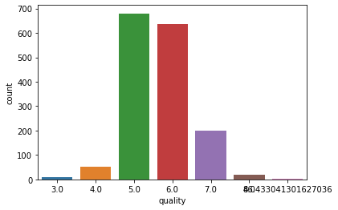

```python
sns.countplot(x = "quality", data = data)
plt.show()
```

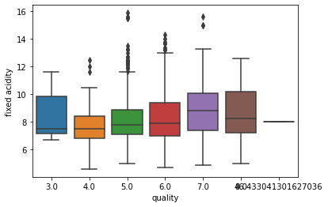

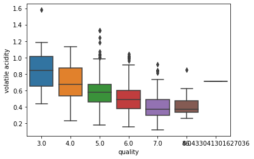

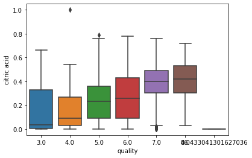

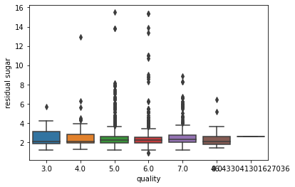

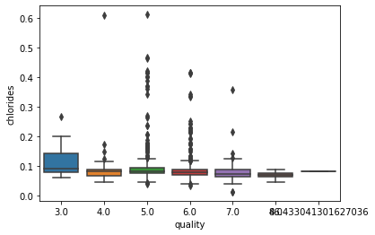

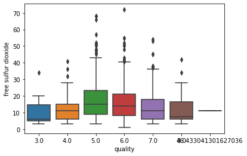

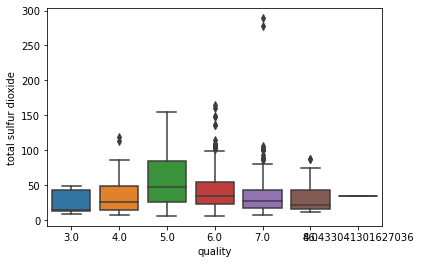

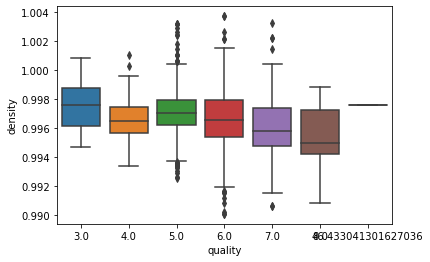

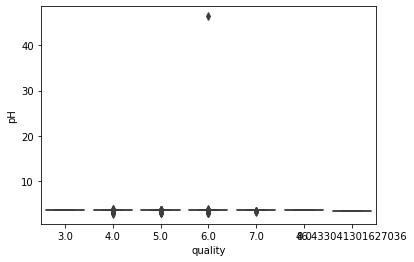

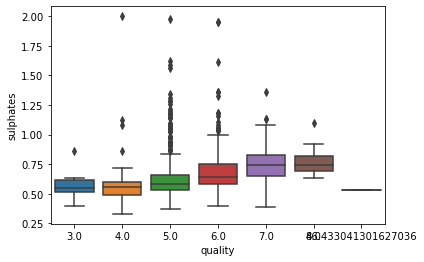

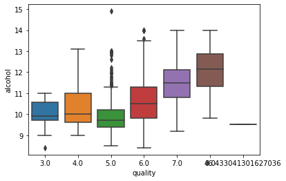

```python
for i in data.columns:
    if i =="quality":
        break
    sns.boxplot("quality",i,data=data)
    plt.show()
```

# Correlation Matrix with Heatmap

1. Correlation is a statistical measure. Data correlation is a way to understand the relationship between multiple values or features in the dataset.
2. Positive Correlation: Two features can be positively correlated with each other when the value of one variable increase then the value of the other variable also increases(also decreases when the other decreases).
3. Negative Correlation: Two features can be negatively correlated with each other when the value of one variable increases and the value of another variable decreases.
4. No Correlation: Two features might not have any relationship with each other. This happens when the value of a variable is changed then the value of other variable is not impacted.

```python
correlation=data.corr()
correlation
```

|  | fixed acidity | volatile acidity | citric acid | residual sugar | chlorides | free sulfur dioxide | total sulfur dioxide | density | pH | sulphates | alcohol | quality |
| --- | --- | --- | --- | --- | --- | --- | --- | --- | --- | --- | --- | --- |
| fixed acidity | 1.000000 | -0.256131 | 0.671703 | 0.114777 | 0.093705 | -0.153794 | -0.112784 | 0.668047 | -0.021158 | 0.183006 | -0.061668 | 0.073340 |
| volatile acidity | -0.256131 | 1.000000 | -0.552496 | 0.001918 | 0.061298 | -0.010504 | 0.076703 | 0.022026 | 0.009381 | -0.260987 | -0.202288 | -0.222142 |
| citric acid | 0.671703 | -0.552496 | 1.000000 | 0.143577 | 0.203823 | -0.060978 | 0.035081 | 0.364947 | -0.007183 | 0.312770 | 0.109903 | 0.112787 |
| residual sugar | 0.114777 | 0.001918 | 0.143577 | 1.000000 | 0.055610 | 0.187049 | 0.200537 | 0.355283 | -0.008321 | 0.005527 | 0.042075 | 0.009388 |
| chlorides | 0.093705 | 0.061298 | 0.203823 | 0.055610 | 1.000000 | 0.005562 | 0.047813 | 0.200632 | -0.023783 | 0.371260 | -0.221141 | -0.083173 |
| free sulfur dioxide | -0.153794 | -0.010504 | -0.060978 | 0.187049 | 0.005562 | 1.000000 | 0.668149 | -0.021946 | -0.020680 | 0.051658 | -0.069408 | -0.040729 |
| total sulfur dioxide | -0.112784 | 0.076703 | 0.035081 | 0.200537 | 0.047813 | 0.668149 | 1.000000 | 0.070743 | -0.000310 | 0.042100 | -0.205914 | -0.122015 |
| density | 0.668047 | 0.022026 | 0.364947 | 0.355283 | 0.200632 | -0.021946 | 0.070743 | 1.000000 | 0.000519 | 0.148506 | -0.496180 | -0.099561 |
| pH | -0.021158 | 0.009381 | -0.007183 | -0.008321 | -0.023783 | -0.020680 | -0.000310 | 0.000519 | 1.000000 | -0.030938 | -0.008884 | 0.011616 |
| sulphates | 0.183006 | -0.260987 | 0.312770 | 0.005527 | 0.371260 | 0.051658 | 0.042100 | 0.148506 | -0.030938 | 1.000000 | 0.093595 | 0.140975 |
| alcohol | -0.061668 | -0.202288 | 0.109903 | 0.042075 | -0.221141 | -0.069408 | -0.205914 | -0.496180 | -0.008884 | 0.093595 | 1.000000 | 0.278294 |
| quality | 0.073340 | -0.222142 | 0.112787 | 0.009388 | -0.083173 | -0.040729 | -0.122015 | -0.099561 | 0.011616 | 0.140975 | 0.278294 | 1.000000 |

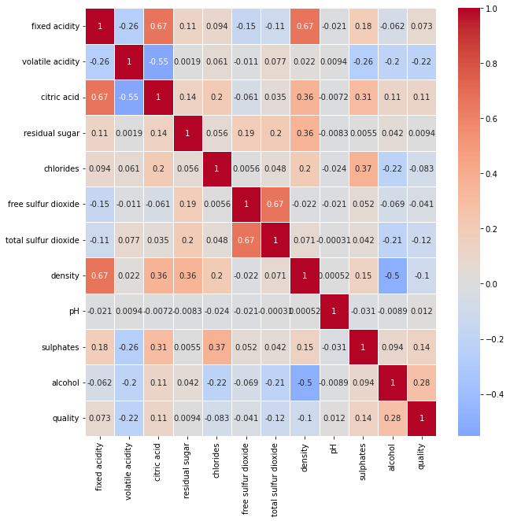

```python
plt.figure(figsize=(10,10))
sns.heatmap(data.corr(),annot=True,linewidth=0.5,center=0,cmap='coolwarm')
plt.show()
```

From the above correlation matrix, we can observe that there is a relatively high positive correlation between fixed acidity and citric acid ,fixed acidity and density .

#### The strongly correlated items are :

1.fixed acidity and citric acid.  
2.free sulphur dioxide and total sulphor dioxide.  
3.fixed acidity and density.